# Homework 4, Ionosphere Data Set

Ömer Çağatay Talikacı

02.01.2021

```r
library(tidyverse)
library(lubridate)
#library(MLmetrics)
library(data.table)
library(knitr)
library(stats)
library(glmnet)
library(ggplot2)
library(readxl)
library(rpart)
library(rattle)
library(caret)
library(randomForest)
library(gbm)
library(rmarkdown)
```

## Dataset Information:

[Ionosphere Data Set.](https://archive.ics.uci.edu/ml/datasets/ionosphere) “This radar data was collected by a system in Goose Bay, Labrador. This system consists of a phased array of 16 high-frequency antennas with a total transmitted power on the order of 6.4 kilowatts. …The targets were free electrons in the ionosphere.”Good" radar returns are those showing evidence of some type of structure in the ionosphere. “Bad” returns are those that do not; their signals pass through the ionosphere."

This is a binary classification problem. I separate the data into two parts as training and test. Four different approach will be applied for determined whether the test instances are “good” or not.

# Reading and Organizing Data

```r
setwd("C:/Users/ÖmerÇağatay/Desktop/Ie 582/hw4")
data<-read.table("ionosphere/ionosphere.data",sep = ",")
bin_ios<-copy(data)
bin_ios$V35<-ifelse(bin_ios$V35=="g",1,0)

sample<-sample.int(nrow(bin_ios),floor(.70*nrow(bin_ios)),replace = F)

ios_train<-bin_ios[sample, ]
ios_test<-bin_ios[-sample, ]
```

# Penalized Regression Approach

For penalized regression approach I will try two different lambda values determined by cross validation. First one is minimum lambda value, lambda.min. Second is the one which gives the most regularized model, lambda.1se. Both determined by cross validation.

## Determining Lambda Values

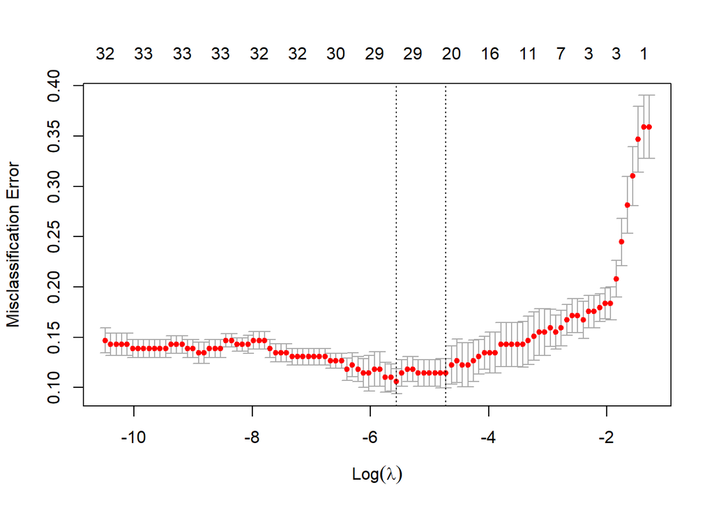

```r
cvfit=cv.glmnet(as.matrix(ios_train[,1:34]),as.matrix(ios_train[,35]),family='binomial',type.measure='class')
plot(cvfit)
```

```r
print( paste("lambda.min: ",cvfit$lambda.min))
```

```
## [1] "lambda.min:  0.00385020460895618"
```

```r
print( paste("lambda.1se: ",cvfit$lambda.1se))
```

```
## [1] "lambda.1se:  0.00889447201161083"
```

### Lambda.min

```r
coef(cvfit,s="lambda.min")
```

```
## 35 x 1 sparse Matrix of class "dgCMatrix"
##                       1
## (Intercept) -11.7929563
## V1            9.2173779
## V2            .
## V3            1.8133094
## V4            .
## V5            1.6545468
## V6            1.1739890
## V7            0.6954721
## V8            2.0828824
## V9            0.9275753
## V10           0.7139429
## V11          -1.0208702
## V12           0.0645988
## V13           0.5336619
## V14           1.4272512
## V15           .
## V16          -1.5637396
## V17           0.1694761
## V18           1.5693087
## V19          -0.8781536
## V20           0.3661876
## V21           0.2840514
## V22          -1.5071218
## V23           1.0741015
## V24           .
## V25           2.0360859
## V26           0.4574969
## V27          -1.7588759
## V28           .
## V29           .
## V30           1.5152664
## V31           2.7465225
## V32          -0.7375860
## V33          -2.0433656
## V34          -2.3534774
```

```r
model<-glmnet(as.matrix(ios_train[,1:34]),as.matrix(ios_train[,35]),alpha = 1,family = "binomial",lambda =cvfit$lambda.min)


predict_pra_train<-predict(model,as.matrix(ios_train[,1:34]))
predict_pra_test<-predict(model,as.matrix(ios_test[,1:34]))

predict_pra_test<-ifelse(predict_pra_test < 0.5,0,1)
predict_pra_train<-ifelse(predict_pra_train < 0.5,0,1)

print(paste("Ratio of correctly classified instances for train:",mean(predict_pra_train==ios_train$V35)))
```

```
## [1] "Ratio of correctly classified instances for train: 0.930612244897959"
```

```r
print(paste("Ratio of correctly classified instances for test:",mean(predict_pra_test==ios_test$V35)))
```

```
## [1] "Ratio of correctly classified instances for test: 0.867924528301887"
```

### Lambda.1se

```r
coef(cvfit,s="lambda.1se")
```

```
## 35 x 1 sparse Matrix of class "dgCMatrix"
##                        1
## (Intercept) -7.542375473
## V1           5.511196357
## V2           .
## V3           1.549143400
## V4           0.388642992
## V5           1.550194646
## V6           0.490684594
## V7           0.739742938
## V8           1.269178379
## V9           .
## V10          0.653094361
## V11          .
## V12          0.002409286
## V13          .
## V14          0.904580857
## V15          .
## V16         -0.236474717
## V17          .
## V18          0.598287863
## V19          .
## V20          .
## V21          .
## V22         -0.865302840
## V23          0.187763043
## V24          .
## V25          1.066872185
## V26          0.141084804
## V27         -1.047662415
## V28          .
## V29          .
## V30          0.846223486
## V31          1.617436138
## V32          .
## V33         -0.665023514
## V34         -1.780068839
```

```r
 model.1se<-glmnet(as.matrix(ios_train[,1:34]),as.matrix(ios_train[,35]),alpha = 1,family = "binomial",lambda =cvfit$lambda.1se)

 predict_pra_train.1se<-predict(model.1se,as.matrix(ios_train[,1:34]))
 predict_pra_test.1se<-predict(model.1se,as.matrix(ios_test[,1:34]))

predict_pra_train.1se<-ifelse(predict_pra_train.1se < 0.5,0,1)
predict_pra_test.1se<-ifelse(predict_pra_test.1se < 0.5,0,1)

print(paste("Ratio of correctly classified instances for train:",mean(predict_pra_train.1se==ios_train$V35)))
```

```
## [1] "Ratio of correctly classified instances for train: 0.918367346938776"
```

```r
print(paste("Ratio of correctly classified instances for test:",mean(predict_pra_test.1se==ios_test$V35)))
```

```
## [1] "Ratio of correctly classified instances for test: 0.867924528301887"
```

```r
test<-c(mean(predict_pra_test.1se==ios_test$V35),mean(predict_pra_test==ios_test$V35))
train<-c(mean(predict_pra_train.1se==ios_train$V35),mean(predict_pra_train==ios_train$V35))
df<-data.frame(test,train)
row.names(df)[c(1,2)]<-c("lambda.1se","lambda.min")

df
```

```
##                 test     train
## lambda.1se 0.8679245 0.9183673
## lambda.min 0.8679245 0.9306122
```

## Comments on PRA

2 different lambda values tried for classification. Firstly both approach works better on train data. Success rates can be seen above table. If we look at the coefficients we can see that lambda.1se discards the noisy variables and use less features. V1 has the biggest impact at both. Success rate for the training data is better for both lambdas. Successively guessed features ratio is around 90% for this approach.